# Project: Exploring Movie Popularity and Revenue

- Introduction
- Data Wrangling
- Exploratory Data Analysis
- Conclusions

# Exploring Movie Popularity and Revenue

Examples of interesting questions that could be answered with this data:

- Are movies with higher budgets more popular?
- Do more popular movies have higher revenue?
- Do movies with higher budgets have higher revenue?
- Do certain directors have higher budgets?
- Do certain directors influence revenue?
- Is there a correlation between directors and movie popularity?
- Are certain genres more popular than others?
- Do certain genres earn more revenue than others?
- Do certain times of year influence popularity?
- Which years have the most popular movies?
- Do certain actors influence popularity?
- Do certain actors influence revenue?
- Are runtime and popularity correlated?

The questions we're going to explore:

- Are movies with higher budgets more popular?
- Do more popular movies have higher revenue?
- Do movies with higher budgets have higher revenue?
- Do certain directors have higher budgets?
- Do certain directors influence revenue?
- Is there a correlation between directors and movie popularity?
- Are runtime and popularity correlated?

```python
#Importing packages/libraries and using our magic word for in-notebook visualizations.

import numpy as np
import pandas as pd
import matplotlib.pyplot as plt
import seaborn as sns

%matplotlib inline
```

## Data Wrangling

### General Properties

Loading data from TMDB, The Movie Database 'tmdb-movies.csv', which uses "," and "|" as a delimeters. Let's take a look at the first few rows using df_movies.head()

```python
df_movies = pd.read_csv('tmdb-movies.csv')
df_movies.head()
```

|  | id | imdb_id | popularity | budget | revenue | original_title | cast | homepage | director | tagline | ... | overview | runtime | genres | production_companies | release_date | vote_count | vote_average | release_year | budget_adj | revenue_adj |
| --- | --- | --- | --- | --- | --- | --- | --- | --- | --- | --- | --- | --- | --- | --- | --- | --- | --- | --- | --- | --- | --- |
| 0 | 135397 | tt0369610 | 32.985763 | 150000000 | 1513528810 | Jurassic World | Chris Pratt\|Bryce Dallas Howard\|Irrfan Khan\|Vi... | http://www.jurassicworld.com/ | Colin Trevorrow | The park is open. | ... | Twenty-two years after the events of Jurassic ... | 124 | Action\|Adventure\|Science Fiction\|Thriller | Universal Studios\|Amblin Entertainment\|Legenda... | 6/9/15 | 5562 | 6.5 | 2015 | 1.379999e+08 | 1.392446e+09 |
| 1 | 76341 | tt1392190 | 28.419936 | 150000000 | 378436354 | Mad Max: Fury Road | Tom Hardy\|Charlize Theron\|Hugh Keays-Byrne\|Nic... | http://www.madmaxmovie.com/ | George Miller | What a Lovely Day. | ... | An apocalyptic story set in the furthest reach... | 120 | Action\|Adventure\|Science Fiction\|Thriller | Village Roadshow Pictures\|Kennedy Miller Produ... | 5/13/15 | 6185 | 7.1 | 2015 | 1.379999e+08 | 3.481613e+08 |
| 2 | 262500 | tt2908446 | 13.112507 | 110000000 | 295238201 | Insurgent | Shailene Woodley\|Theo James\|Kate Winslet\|Ansel... | http://www.thedivergentseries.movie/#insurgent | Robert Schwentke | One Choice Can Destroy You | ... | Beatrice Prior must confront her inner demons ... | 119 | Adventure\|Science Fiction\|Thriller | Summit Entertainment\|Mandeville Films\|Red Wago... | 3/18/15 | 2480 | 6.3 | 2015 | 1.012000e+08 | 2.716190e+08 |
| 3 | 140607 | tt2488496 | 11.173104 | 200000000 | 2068178225 | Star Wars: The Force Awakens | Harrison Ford\|Mark Hamill\|Carrie Fisher\|Adam D... | http://www.starwars.com/films/star-wars-episod... | J.J. Abrams | Every generation has a story. | ... | Thirty years after defeating the Galactic Empi... | 136 | Action\|Adventure\|Science Fiction\|Fantasy | Lucasfilm\|Truenorth Productions\|Bad Robot | 12/15/15 | 5292 | 7.5 | 2015 | 1.839999e+08 | 1.902723e+09 |
| 4 | 168259 | tt2820852 | 9.335014 | 190000000 | 1506249360 | Furious 7 | Vin Diesel\|Paul Walker\|Jason Statham\|Michelle ... | http://www.furious7.com/ | James Wan | Vengeance Hits Home | ... | Deckard Shaw seeks revenge against Dominic Tor... | 137 | Action\|Crime\|Thriller | Universal Pictures\|Original Film\|Media Rights ... | 4/1/15 | 2947 | 7.3 | 2015 | 1.747999e+08 | 1.385749e+09 |

5 rows × 21 columns

Now let's check how many rows and columns the data has.

```python
df_movies.shape
```

```
(10866, 21)
```

This function gives us a quick overview of column names and data types, as well as non-null values.

```python
df_movies.info()
```

```
<class 'pandas.core.frame.DataFrame'>
RangeIndex: 10866 entries, 0 to 10865
Data columns (total 21 columns):
 #   Column                Non-Null Count  Dtype
---  ------                --------------  -----
 0   id                    10866 non-null  int64
 1   imdb_id               10856 non-null  object
 2   popularity            10866 non-null  float64
 3   budget                10866 non-null  int64
 4   revenue               10866 non-null  int64
 5   original_title        10866 non-null  object
 6   cast                  10790 non-null  object
 7   homepage              2936 non-null   object
 8   director              10822 non-null  object
 9   tagline               8042 non-null   object
 10  keywords              9373 non-null   object
 11  overview              10862 non-null  object
 12  runtime               10866 non-null  int64
 13  genres                10843 non-null  object
 14  production_companies  9836 non-null   object
 15  release_date          10866 non-null  object
 16  vote_count            10866 non-null  int64
 17  vote_average          10866 non-null  float64
 18  release_year          10866 non-null  int64
 19  budget_adj            10866 non-null  float64
 20  revenue_adj           10866 non-null  float64
dtypes: float64(4), int64(6), object(11)
memory usage: 1.7+ MB
```

Here, we're getting more familiar with our data. We can see some quick calculations to start forming our business questions.

```python
df_movies.describe()
```

|  | id | popularity | budget | revenue | runtime | vote_count | vote_average | release_year | budget_adj | revenue_adj |
| --- | --- | --- | --- | --- | --- | --- | --- | --- | --- | --- |
| count | 10866.000000 | 10866.000000 | 1.086600e+04 | 1.086600e+04 | 10866.000000 | 10866.000000 | 10866.000000 | 10866.000000 | 1.086600e+04 | 1.086600e+04 |
| mean | 66064.177434 | 0.646441 | 1.462570e+07 | 3.982332e+07 | 102.070863 | 217.389748 | 5.974922 | 2001.322658 | 1.755104e+07 | 5.136436e+07 |
| std | 92130.136561 | 1.000185 | 3.091321e+07 | 1.170035e+08 | 31.381405 | 575.619058 | 0.935142 | 12.812941 | 3.430616e+07 | 1.446325e+08 |
| min | 5.000000 | 0.000065 | 0.000000e+00 | 0.000000e+00 | 0.000000 | 10.000000 | 1.500000 | 1960.000000 | 0.000000e+00 | 0.000000e+00 |
| 25% | 10596.250000 | 0.207583 | 0.000000e+00 | 0.000000e+00 | 90.000000 | 17.000000 | 5.400000 | 1995.000000 | 0.000000e+00 | 0.000000e+00 |
| 50% | 20669.000000 | 0.383856 | 0.000000e+00 | 0.000000e+00 | 99.000000 | 38.000000 | 6.000000 | 2006.000000 | 0.000000e+00 | 0.000000e+00 |
| 75% | 75610.000000 | 0.713817 | 1.500000e+07 | 2.400000e+07 | 111.000000 | 145.750000 | 6.600000 | 2011.000000 | 2.085325e+07 | 3.369710e+07 |
| max | 417859.000000 | 32.985763 | 4.250000e+08 | 2.781506e+09 | 900.000000 | 9767.000000 | 9.200000 | 2015.000000 | 4.250000e+08 | 2.827124e+09 |

Let's check to see which columns have null values and how many. Will we need to fill these values? Can we use the calculations from the describe function?

```python
df_movies.isnull().sum()
```

```
id                         0
imdb_id                   10
popularity                 0
budget                     0
revenue                    0
original_title             0
cast                      76
homepage                7930
director                  44
tagline                 2824
keywords                1493
overview                   4
runtime                    0
genres                    23
production_companies    1030
release_date               0
vote_count                 0
vote_average               0
release_year               0
budget_adj                 0
revenue_adj                0
dtype: int64
```

# Data Cleaning

Tasks:

- Drop unnecessary columns.
- Check data types - do any need to be changed?
- Fill or drop NULL values.
- Check for duplicates, drop if present.

Let's take another look at the questions we want to explore to decide which columns we can safely remove.

The questions we're going to explore:

- Are movies with higher budgets more popular?
- Do more popular movies have higher revenue?
- Do movies with higher budgets have higher revenue?
- Do certain directors have higher budgets?
- Do certain directors influence revenue?
- Is there a correlation between directors and movie popularity?
- Are runtime and popularity correlated?

```python
df_movies.drop(['imdb_id','cast','homepage','tagline','keywords','overview', 'genres','production_companies', 'release_date','vote_count','vote_average','release_year'], axis=1, inplace=True)
```

```python
df_movies.head()
```

|  | id | popularity | budget | revenue | original_title | director | runtime | budget_adj | revenue_adj |
| --- | --- | --- | --- | --- | --- | --- | --- | --- | --- |
| 0 | 135397 | 32.985763 | 150000000 | 1513528810 | Jurassic World | Colin Trevorrow | 124 | 1.379999e+08 | 1.392446e+09 |
| 1 | 76341 | 28.419936 | 150000000 | 378436354 | Mad Max: Fury Road | George Miller | 120 | 1.379999e+08 | 3.481613e+08 |
| 2 | 262500 | 13.112507 | 110000000 | 295238201 | Insurgent | Robert Schwentke | 119 | 1.012000e+08 | 2.716190e+08 |
| 3 | 140607 | 11.173104 | 200000000 | 2068178225 | Star Wars: The Force Awakens | J.J. Abrams | 136 | 1.839999e+08 | 1.902723e+09 |
| 4 | 168259 | 9.335014 | 190000000 | 1506249360 | Furious 7 | James Wan | 137 | 1.747999e+08 | 1.385749e+09 |

This is what our dataset now looks like. Let's doublecheck the datatypes to see if we need to make any conversions.

```python
df_movies.dtypes
```

```
id                  int64
popularity        float64
budget              int64
revenue             int64
original_title     object
director           object
runtime             int64
budget_adj        float64
revenue_adj       float64
dtype: object
```

Looks good! Let's check our remaining columns for null values.

```python
df_movies.isnull().sum()
```

```
id                 0
popularity         0
budget             0
revenue            0
original_title     0
director          44
runtime            0
budget_adj         0
revenue_adj        0
dtype: int64
```

It looks like only the director column contains null values. We can't fill that in with a numerical value, so let's drop them.

```python
df_movies_v1 = df_movies.dropna()
```

```python
df_movies_v1.isnull().sum()
```

```
id                0
popularity        0
budget            0
revenue           0
original_title    0
director          0
runtime           0
budget_adj        0
revenue_adj       0
dtype: int64
```

We successfully dropped the null values from the director column! Let's save our data then move on to duplicates.

```python
df_movies_v1.to_csv('tmdb_movies_v2.csv', index=False)
```

```python
df_movies_v2 = pd.read_csv('tmdb_movies_v2.csv')
```

```python
df_movies_v2.head()
```

|  | id | popularity | budget | revenue | original_title | director | runtime | budget_adj | revenue_adj |
| --- | --- | --- | --- | --- | --- | --- | --- | --- | --- |
| 0 | 135397 | 32.985763 | 150000000 | 1513528810 | Jurassic World | Colin Trevorrow | 124 | 1.379999e+08 | 1.392446e+09 |
| 1 | 76341 | 28.419936 | 150000000 | 378436354 | Mad Max: Fury Road | George Miller | 120 | 1.379999e+08 | 3.481613e+08 |
| 2 | 262500 | 13.112507 | 110000000 | 295238201 | Insurgent | Robert Schwentke | 119 | 1.012000e+08 | 2.716190e+08 |
| 3 | 140607 | 11.173104 | 200000000 | 2068178225 | Star Wars: The Force Awakens | J.J. Abrams | 136 | 1.839999e+08 | 1.902723e+09 |
| 4 | 168259 | 9.335014 | 190000000 | 1506249360 | Furious 7 | James Wan | 137 | 1.747999e+08 | 1.385749e+09 |

```python
df_movies_v2.duplicated().sum()
```

```
1
```

```python
#drop duplicate

df_movies_v2.drop_duplicates(inplace=True)
```

Looks like we have 1 duplicate. Let's drop it below.

Let's save our clean data then check how many unique values are under the director column.

```python
#Saving our clean data to df_movies_clean

df_movies_v2.to_csv('tmdb_movies_clean.csv', index=False)
```

```python
#Load our clean data file

df_movies_clean = pd.read_csv('tmdb_movies_clean.csv')
```

```python
df_movies_clean.director.nunique()
```

```
5067
```

We have 5067 different director values. We will need to use filters instead of graphs to find the directors associated with the most popular and highest earning movies.

## Exploratory Data Analysis

Our *updated* questions:

- Are movies with higher budgets more popular?
- Do more popular movies have higher revenue?
- Do movies with higher budgets have higher revenue?
- Are runtime and popularity correlated?
- Do movies with longer runtimes have higher revenue?
- Which movies have the highest revenue (top 10)? Who directed them?
- Which movies are the most popular (top 10)? Who directed them?

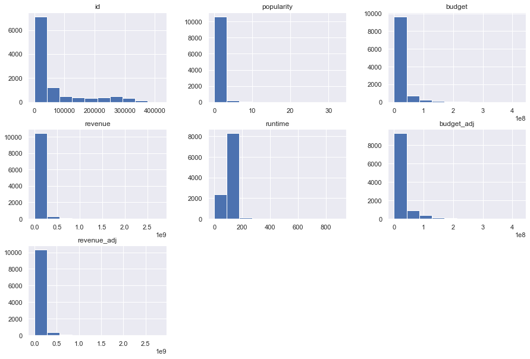

```python
#View histograms of each variable in new, clean data
df_movies_clean.hist(figsize=(15,10));
```

Here we have histograms of each variable we're going to analyze and compare. Notice they are skewed to the right.

#### Function to return averages

This function will be used for further Exploratory Data Analysis (EDA). It returns the mean and median of a specific column.

```python
#Defines a function to get the averages of a column (col), returns the mean and median.
def averages(col):
    avgs_mean = df_movies_clean[col].mean()
    avgs_median = df_movies_clean[col].median()


    return avgs_mean, avgs_median
```

```python
#These visualizations use the Seaborn package. These are called pairplots, which show the distribution of each variable and their relationships.

def popbudgrev_func(col):
    pop_budg_rev_list = df_movies_clean.columns[1:4]
    sns.pairplot(df_movies_clean[pop_budg_rev_list], hue=col, height=3.5);
```

### Which factors influence a movie's popularity?

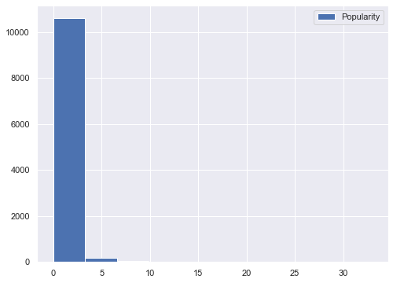

```python
#Let's start with a histogram of popularity

df_movies_clean.popularity.hist(figsize=(8,6), label='Popularity')
plt.legend();
```

Popularity is skewed to the right.

```python
#filter for top 10 most popular with title and director

df_movies_clean.nlargest(10,'popularity')
```

|  | id | popularity | budget | revenue | original_title | director | runtime | budget_adj | revenue_adj |
| --- | --- | --- | --- | --- | --- | --- | --- | --- | --- |
| 0 | 135397 | 32.985763 | 150000000 | 1513528810 | Jurassic World | Colin Trevorrow | 124 | 1.379999e+08 | 1.392446e+09 |
| 1 | 76341 | 28.419936 | 150000000 | 378436354 | Mad Max: Fury Road | George Miller | 120 | 1.379999e+08 | 3.481613e+08 |
| 626 | 157336 | 24.949134 | 165000000 | 621752480 | Interstellar | Christopher Nolan | 169 | 1.519800e+08 | 5.726906e+08 |
| 627 | 118340 | 14.311205 | 170000000 | 773312399 | Guardians of the Galaxy | James Gunn | 121 | 1.565855e+08 | 7.122911e+08 |
| 2 | 262500 | 13.112507 | 110000000 | 295238201 | Insurgent | Robert Schwentke | 119 | 1.012000e+08 | 2.716190e+08 |
| 628 | 100402 | 12.971027 | 170000000 | 714766572 | Captain America: The Winter Soldier | Joe Russo\|Anthony Russo | 136 | 1.565855e+08 | 6.583651e+08 |
| 1321 | 11 | 12.037933 | 11000000 | 775398007 | Star Wars | George Lucas | 121 | 3.957559e+07 | 2.789712e+09 |
| 629 | 245891 | 11.422751 | 20000000 | 78739897 | John Wick | Chad Stahelski\|David Leitch | 101 | 1.842182e+07 | 7.252661e+07 |
| 3 | 140607 | 11.173104 | 200000000 | 2068178225 | Star Wars: The Force Awakens | J.J. Abrams | 136 | 1.839999e+08 | 1.902723e+09 |
| 630 | 131631 | 10.739009 | 125000000 | 752100229 | The Hunger Games: Mockingjay - Part 1 | Francis Lawrence | 123 | 1.151364e+08 | 6.927528e+08 |

There doesn't appear to be a correlation between director and popularity. The most popular movie is Jurassic World.

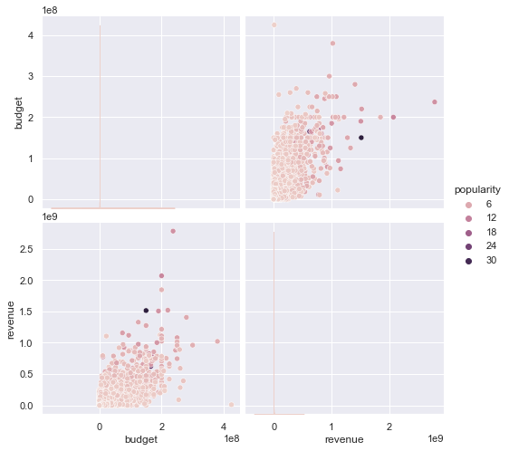

```python
popbudgrev_func('popularity')
```

Let's now take a look at some other visualizations to see if budget, revenue, adjusted budget and revenue, and runtime have any correleation with popularity.

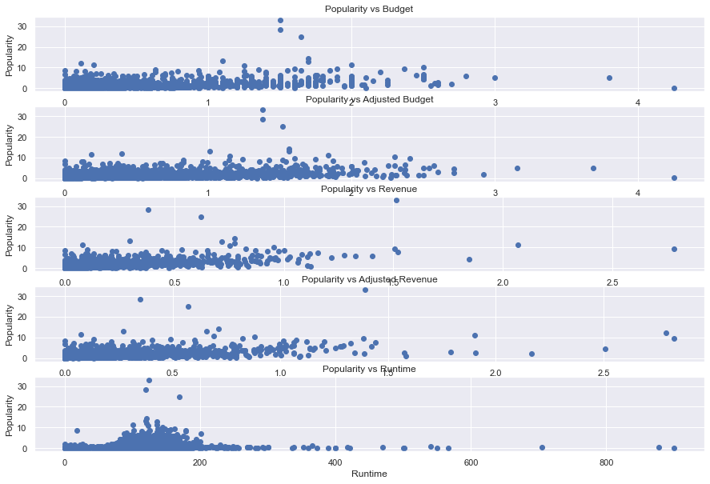

```python
#In this updated report, we've switched from individual scatterplots to subplot functions to streamline the code and condense the visualizations.

#Popularity vs Budget
fig, ax = plt.subplots(5, figsize=(15, 10))
ax[0].scatter(x = df_movies_clean['budget'], y = df_movies_clean['popularity'])
ax[0].set_xlabel("Budget")
ax[0].set_ylabel("Popularity")
ax[0].set_title("Popularity vs Budget")

#Popularity vs Adjusted Budget
ax[1].scatter(x = df_movies_clean['budget_adj'], y = df_movies_clean['popularity'])
ax[1].set_xlabel("Adjusted Budget")
ax[1].set_ylabel("Popularity")
ax[1].set_title("Popularity vs Adjusted Budget")

#Popularity vs Revenue
ax[2].scatter(x = df_movies_clean['revenue'], y=df_movies_clean['popularity'])
ax[2].set_xlabel("Revenue")
ax[2].set_ylabel("Popularity")
ax[2].set_title("Popularity vs Revenue")

#Popularity vs Adjusted Revenue
ax[3].scatter(x=df_movies_clean['revenue_adj'], y=df_movies_clean['popularity'])
ax[3].set_xlabel("Adjusted Revenue")
ax[3].set_ylabel("Popularity")
ax[3].set_title("Popularity vs Adjusted Revenue")

#Popularity vs Runtime
ax[4].scatter(x=df_movies_clean['runtime'], y=df_movies_clean['popularity'])
ax[4].set_xlabel("Runtime")
ax[4].set_ylabel("Popularity")
ax[4].set_title("Popularity vs Runtime")

plt.show()
```

The revenue scatterplots don't show a very strong correlation between revenue and popularity. Further investigation is needed. We have added revenue and budget scatterplots with line regressions below.

Now let's look at runtime.

The runtime scatterplot shows that movies between 1 and 3.5 hours tend to be more popular.

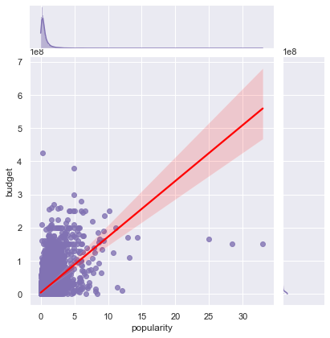

```python
sns.set(style="darkgrid")
g = sns.jointplot(x = "popularity", y = "budget", data=df_movies_clean, kind="reg", joint_kws={'line_kws':{'color':'red' }},
                  #xlim=(0, 60), ylim=(0, 12),
                  color="m", height=6)
```

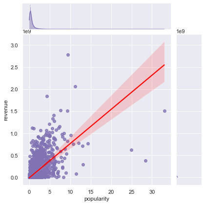

```python
sns.set(style="darkgrid")
g = sns.jointplot(x = "popularity", y = "revenue", data=df_movies_clean, kind="reg", joint_kws={'line_kws':{'color':'red' }},
                  #xlim=(0, 60), ylim=(0, 12),
                  color="m", height=6)
```

With the line of regression, we can see that the plot points don't follow the trend. They are correlated in specific ranges. This is consistent with our previous analysis.

### Which factors influence a movie's revenue?

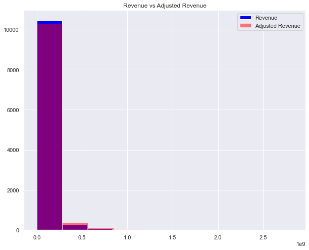

```python
#Let's start with histograms of revenue and revenue_adj
df_movies_clean.revenue.hist(figsize=(10,8), color='blue', alpha=1, label='Revenue')
df_movies_clean.revenue_adj.hist(color='red', alpha=0.5, label='Adjusted Revenue')
plt.legend()
plt.title('Revenue vs Adjusted Revenue')
plt.show()
```

We can see that both revenue and revenue_adj are skewed to the right.

```python
#filter for top 10 highest revenue with title and director

df_movies_clean.nlargest(10,'revenue')
```

|  | id | popularity | budget | revenue | original_title | director | runtime | budget_adj | revenue_adj |
| --- | --- | --- | --- | --- | --- | --- | --- | --- | --- |
| 1378 | 19995 | 9.432768 | 237000000 | 2781505847 | Avatar | James Cameron | 162 | 2.408869e+08 | 2.827124e+09 |
| 3 | 140607 | 11.173104 | 200000000 | 2068178225 | Star Wars: The Force Awakens | J.J. Abrams | 136 | 1.839999e+08 | 1.902723e+09 |
| 5198 | 597 | 4.355219 | 200000000 | 1845034188 | Titanic | James Cameron | 194 | 2.716921e+08 | 2.506406e+09 |
| 4332 | 24428 | 7.637767 | 220000000 | 1519557910 | The Avengers | Joss Whedon | 143 | 2.089437e+08 | 1.443191e+09 |
| 0 | 135397 | 32.985763 | 150000000 | 1513528810 | Jurassic World | Colin Trevorrow | 124 | 1.379999e+08 | 1.392446e+09 |
| 4 | 168259 | 9.335014 | 190000000 | 1506249360 | Furious 7 | James Wan | 137 | 1.747999e+08 | 1.385749e+09 |
| 14 | 99861 | 5.944927 | 280000000 | 1405035767 | Avengers: Age of Ultron | Joss Whedon | 141 | 2.575999e+08 | 1.292632e+09 |
| 3346 | 12445 | 5.711315 | 125000000 | 1327817822 | Harry Potter and the Deathly Hallows: Part 2 | David Yates | 130 | 1.211748e+08 | 1.287184e+09 |
| 5388 | 109445 | 6.112766 | 150000000 | 1274219009 | Frozen | Chris Buck\|Jennifer Lee | 102 | 1.404050e+08 | 1.192711e+09 |
| 5391 | 68721 | 4.946136 | 200000000 | 1215439994 | Iron Man 3 | Shane Black | 130 | 1.872067e+08 | 1.137692e+09 |

Directors may have an influence on revenue. Both James Cameron and Joss Whedon appear twice in the top 10. Here, Avatar is the movie with highest revenue. Let's check again with the adjusted revenue.

```python
#filter for top 10 highest revenue with title and director

df_movies_clean.nlargest(10,'revenue_adj')
```

|  | id | popularity | budget | revenue | original_title | director | runtime | budget_adj | revenue_adj |
| --- | --- | --- | --- | --- | --- | --- | --- | --- | --- |
| 1378 | 19995 | 9.432768 | 237000000 | 2781505847 | Avatar | James Cameron | 162 | 2.408869e+08 | 2.827124e+09 |
| 1321 | 11 | 12.037933 | 11000000 | 775398007 | Star Wars | George Lucas | 121 | 3.957559e+07 | 2.789712e+09 |
| 5198 | 597 | 4.355219 | 200000000 | 1845034188 | Titanic | James Cameron | 194 | 2.716921e+08 | 2.506406e+09 |
| 10549 | 9552 | 2.010733 | 8000000 | 441306145 | The Exorcist | William Friedkin | 122 | 3.928928e+07 | 2.167325e+09 |
| 9763 | 578 | 2.563191 | 7000000 | 470654000 | Jaws | Steven Spielberg | 124 | 2.836275e+07 | 1.907006e+09 |
| 3 | 140607 | 11.173104 | 200000000 | 2068178225 | Star Wars: The Force Awakens | J.J. Abrams | 136 | 1.839999e+08 | 1.902723e+09 |
| 8847 | 601 | 2.900556 | 10500000 | 792910554 | E.T. the Extra-Terrestrial | Steven Spielberg | 115 | 2.372625e+07 | 1.791694e+09 |
| 8052 | 1642 | 1.136610 | 22000000 | 1106279658 | The Net | Irwin Winkler | 114 | 3.148127e+07 | 1.583050e+09 |
| 10067 | 12230 | 2.631987 | 4000000 | 215880014 | One Hundred and One Dalmatians | Clyde Geronimi\|Hamilton Luske\|Wolfgang Reitherman | 79 | 2.917944e+07 | 1.574815e+09 |
| 4332 | 24428 | 7.637767 | 220000000 | 1519557910 | The Avengers | Joss Whedon | 143 | 2.089437e+08 | 1.443191e+09 |

Interesting! James Cameron still acounts for 2 of the top 10 highest earning movies, but now so does Steven Spielberg. Joss Whedon has 1 instead of 2. Avatar is still the movie with highest revenue. Directors may have an influence over revenue, but this analysis is inconclusive. *For my own curiosity, I did expand these queries to the top 25 and found similar results.*

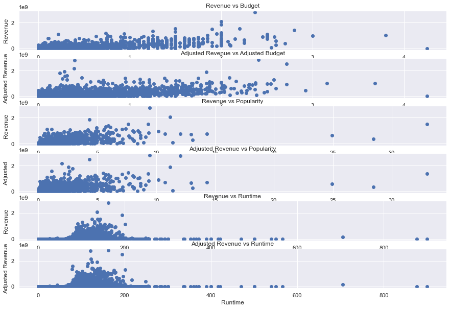

```python
#In this updated report, we've switched from individual scatterplots to subplot functions to streamline the code and condense the visualizations.

#Revenue vs Budget
fig, ax = plt.subplots(6, figsize=(15, 10))
ax[0].scatter(x = df_movies_clean['budget'], y = df_movies_clean['revenue'])
ax[0].set_xlabel("Budget")
ax[0].set_ylabel("Revenue")
ax[0].set_title("Revenue vs Budget")

#Adjusted Revenue vs Adjusted Budget
ax[1].scatter(x = df_movies_clean['budget_adj'], y = df_movies_clean['revenue_adj'])
ax[1].set_xlabel("Adjusted Budget")
ax[1].set_ylabel("Adjusted Revenue")
ax[1].set_title("Adjusted Revenue vs Adjusted Budget")

#Revenue vs Popularity
ax[2].scatter(x = df_movies_clean['popularity'], y=df_movies_clean['revenue'])
ax[2].set_xlabel("Popularity")
ax[2].set_ylabel("Revenue")
ax[2].set_title("Revenue vs Popularity")

#Adjusted Revenue vs Popularity
ax[3].scatter(x=df_movies_clean['popularity'], y=df_movies_clean['revenue_adj'])
ax[3].set_xlabel("Popularity")
ax[3].set_ylabel("Adjusted")
ax[3].set_title("Adjusted Revenue vs Popularity")

#Runtime vs Revenue
ax[4].scatter(x=df_movies_clean['runtime'], y=df_movies_clean['revenue'])
ax[4].set_xlabel("Runtime")
ax[4].set_ylabel("Revenue")
ax[4].set_title("Revenue vs Runtime")

#Runtime vs Adjusted Revenue

ax[5].scatter(x=df_movies_clean['runtime'], y=df_movies_clean['revenue_adj'])
ax[5].set_xlabel("Runtime")
ax[5].set_ylabel("Adjusted Revenue")
ax[5].set_title("Adjusted Revenue vs Runtime")

plt.show()
```

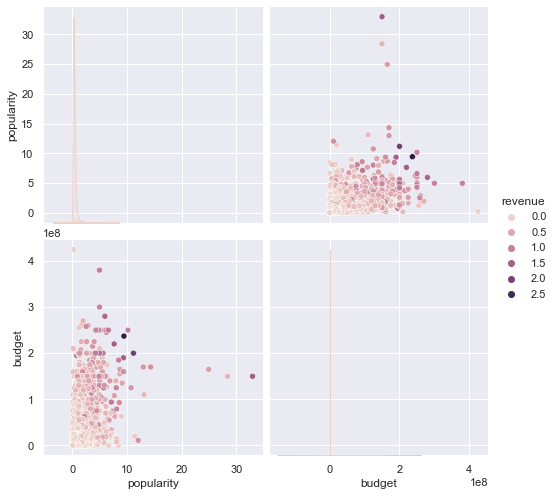

```python
#Let's call our pairplot function to see the relationships between revenue, budget, and popularity
popbudgrev_func('revenue')
```

We've added plots with regression lines for Revenue vs Popularity and Revenue vs Budget.

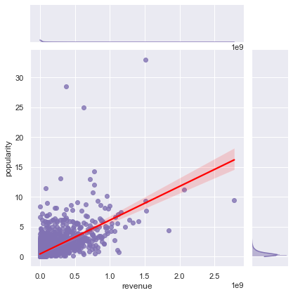

```python
sns.set(style="darkgrid")
g = sns.jointplot(x = "revenue", y = "popularity", data=df_movies_clean, kind="reg", joint_kws={'line_kws':{'color':'red' }},
                  #xlim=(0, 60), ylim=(0, 12),
                  color="m", height=6)
```

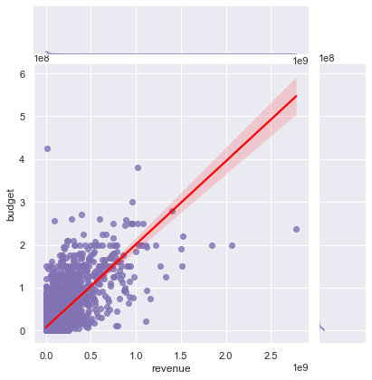

```python
sns.set(style="darkgrid")
g = sns.jointplot(x = "revenue", y = "budget", data=df_movies_clean, kind="reg", joint_kws={'line_kws':{'color':'red' }},
                  #xlim=(0, 60), ylim=(0, 12),
                  color="m", height=6)
```

```python
df_movies_clean.groupby(['budget','budget_adj']).revenue.max()
```

```
budget     budget_adj
0          0.000000e+00     253625427
1          9.210911e-01             0
           9.693980e-01          1378
           1.012787e+00             0
           1.309053e+00           100
                              ...
270000000  2.920507e+08     391081192
280000000  2.575999e+08    1405035767
300000000  3.155006e+08     961000000
380000000  3.683713e+08    1021683000
425000000  4.250000e+08      11087569
Name: revenue, Length: 2611, dtype: int64
```

Both runtime scatter plots show that movies between an hour and 3.5 hours tend to have higher revenue. Runtime has a similar correlation with popularity. Due to this similarity, let's take a closer look at runtime.

```python
#Let's call our function to get averages and pass in the runtime column.
averages('runtime')
```

```
(102.13030219018574, 99.0)
```

So according to the results of our function, the mean is 102.13 minutes of runtime. The median is 99 minutes.

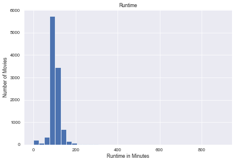

```python
sns.set_style('darkgrid')

plt.figure(figsize=(9,6), dpi=50)
plt.xlabel('Runtime in Minutes')
plt.ylabel('Number of Movies')
plt.title('Runtime')

plt.hist(df_movies_clean['runtime'], bins=35);
```

This again shows that the number of movies in the 1 to 3.5 range is higher than in others. This makes sense and explains why our data trends show more popular and higher revenue in this range.

```python
#Let's see the revenue and popularity grouped runtime's mean. The most popular and most revenue fall into the same time range.
df_movies_clean.groupby(['revenue','popularity']).runtime.mean()
```

```
revenue     popularity
0           0.000188      103.0
            0.000620       92.0
            0.000973      105.0
            0.001115      135.0
            0.001315      360.0
                          ...
1513528810  32.985763     124.0
1519557910  7.637767      143.0
1845034188  4.355219      194.0
2068178225  11.173104     136.0
2781505847  9.432768      162.0
Name: runtime, Length: 10794, dtype: float64
```

## Conclusions

In this section, we will summarize our findings.

The questions we explored:

- Are movies with higher budgets more popular?
- Do more popular movies have higher revenue?
- Do movies with higher budgets have higher revenue?
- Are runtime and popularity correlated?
- Do movies with longer runtimes have higher revenue?
- Which movies have the highest revenue (top 10)? Who directed them?
- Which movies are the most popular (top 10)? Who directed them?

### Summary

This broad overview of the available data gives us the ability to conceptualize the available variables and visualize the possible relationships between them. In a way, it provides a roadmap to further statistical analysis. The disadvantage is that we haven't made concrete, stastical conclusions for decision making. Our analysis is dependent on the limitations of the data provided, given that there were missing and null values. We did not perform deeper stastical calculations and therefore can only make assumptions and not solid conclusions with our analysis.

With our analysis:

Our Exploratory Data Analysis (EDA) with directors was inconclusive and requires more investigation as well.

We can also conclude that movies with runtimes between 1 and 3.5 hours tend to be more popular and earn more revenue. We also discovered that most movies fall into this range. Further investigation is needed.

There are many factors that could be explored with more in-depth analysis on this topic, however we now have a good understanding about how popularity, revenue, budget, and runtime influence each other.